# Skalowanie i diagnostyka IRT modelu jednowymiarowego

Karolina Świst, Tomasz Żółtak

23 września 2016

# Skalowanie wzrostu

Dane, których będziemy używać pochodzą z ankiety (internetowej) przeprowadzonej wśród uczestników trzeciego *Spotkania Entuzjastów R*, które odbyło się w Warszawie 24 kwietnia 2014 r. 43 respondentów udzieliło odpowiedzi *tak* lub *nie* na 12 pytań, związanych z funkcjonowaniem w codziennym życiu w sytuacjach, w których wzrost bywa istotny. Poza tym poproszono ich o podanie wprost swojego wzrostu.

Zbiór danych zawarty został w pakiecie ‘KTT’, o zainstalowanie którego byli Państwo proszeni przed warsztatami. Załadowanie pakietu do programu R komendą ‘library()’ sprawi, że będzie on dostępny do analiz.

```r
> library(KTT)
> print(opisTestuWzrost[, -c(2, 4, 6)], right = FALSE)
   zmienna
1  wzrost
2  rozmiar_buta
3  p1_p
4  p2_p
5  p3_p
6  p4_p
7  p5_p
8  p6_n
9  p7_p
10 p8_n
11 p9_n
12 p10_p
13 p11_n
14 p12_n
   etykieta
1  Wzrost badanego [cm]
2  Rozmiar buta badanego (numeracja europejska)
3  P1. Zdarza mi się słyszeć, że mógłbym zostać koszykarzem.
4  P2. W autobusie mogę wygodnie trzymać się górnych (poziomych) uchwytów.
5  P3. Łóżka w hotelach są dla mnie zwykle za krótkie.
6  P4. Inni ludzie proszą mnie, żebym podał im rzeczy, które leżą wysoko.
7  P5. Wchodząc do pomieszczeń muszę nieraz uważać, aby nie uderzyć się w głowę.
8  P6. Sięganie po rzeczy z szafek wiszących w kuchni sprawia mi trudność.
9  P7. Siedząc w samochodzie (...) mam często zbyt mało miejsca na nogi.
10 P8. Wolał(a)bym być wyższy.
11 P9. Rozmawiając z innymi często muszę zadzierać głowę.
12 P10. Na większość ludzi mogę patrzeć z góry (dosłownie, nie w przenośni).
13 P11. Na fotografiach grupowych zwykle stoję w pierwszym rzędzie.
14 P12. Na koncertach muszę stać blisko sceny (ekranu), bo inaczej nic nie widzę.
   poprawna_odpowiedz
1
2
3  Tak
4  Tak
5  Tak
6  Tak
7  Tak
8  Nie
9  Tak
10 Nie
11 Nie
12 Tak
13 Nie
14 Nie
> summary(daneWzrost)
     wzrost       rozmiar_buta  p1_p     p2_p     p3_p     p4_p
 Min.   :160.0   43     : 9    Nie:42   Nie: 3   Nie:35   Nie:16
 1st Qu.:175.0   39     : 5    Tak: 1   Tak:40   Tak: 8   Tak:27
 Median :180.0   42     : 5
 Mean   :179.1   44     : 5
 3rd Qu.:185.0   46     : 5
 Max.   :190.0   45     : 4
                 (Other):10
  p5_p     p6_n     p7_p     p8_n     p9_n    p10_p    p11_n    p12_n
    : 1   Nie:40   Nie:18   Nie:29   Nie:42   Nie:34   Nie:38   Nie:34
 Nie:34   Tak: 3   Tak:25   Tak:14   Tak: 1   Tak: 9   Tak: 5   Tak: 9
 Tak: 8
```

Jak widać, dane przechowywane są w postaci odpowiedzi, przy czym w zależności od pytania na raczej wyższy wzrost wskazuje albo odpowiedź *tak* albo odpowiedź *nie*. Aby móc je dalej analizować, przekształcimy je na *punkty* przy pomocy funkcji ‘przypisz_punktacje()’ z pakietu ‘KTT’, a wynik jej działania przypiszmy do obiektu ‘wynikiWzrost’.

```r
> wynikiWzrost = przypisz_punktacje(daneWzrost, opisTestuWzrost, verbose = FALSE)
```

## Zapozananie z testem

Zanim przystąpimy do skalowania IRT, przyjrzyjmy się statystykom KTT zadań, korzystając z funkcji ‘parametry_zadan()’ (z pakietu ‘KTT’). Obliczone parametry przypiszmy do obiektu ‘parKTT’.

```r
> parKTT = parametry_zadan(wynikiWzrost)
Parametry zadań:

test złożony z 12 zadań
43 obserwacje (zdających)
w macierzy danych nie ma braków danych

rzetelność testu:
alfa Cronbacha  = 0.710
alfa Feldt-Raju = 0.736

 zadanie min. maks. trudność łatwość  MR-P MR-PBZ MR-DS rzetBZ-aC
    p1_p    0     1     0.98    0.02 0.288  0.221 0.788 0.707
    p2_p    0     1     0.07    0.93 0.383  0.275 0.728 0.701
    p3_p    0     1     0.81    0.19 0.084 -0.098 0.121 0.753 (!)
    p4_p    0     1     0.37    0.63 0.717  0.577 0.917 0.649
    p5_p    0     1     0.81    0.19 0.501  0.347 0.728 0.691
    p6_n    0     1     0.07    0.93 0.383  0.275 0.728 0.701
    p7_p    0     1     0.42    0.58 0.725  0.584 0.916 0.647
    p8_n    0     1     0.33    0.67 0.671  0.521 0.873 0.660
    p9_n    0     1     0.02    0.98 0.360  0.296 0.985 0.703
   p10_p    0     1     0.79    0.21 0.559  0.408 0.791 0.682
   p11_n    0     1     0.12    0.88 0.575  0.461 0.942 0.677
   p12_n    0     1     0.21    0.79 0.480  0.314 0.678 0.696
 rzetBZ-aFR
  0.731
  0.728
  0.776 (!)
  0.672
  0.720
  0.729
  0.673
  0.688
  0.727
  0.713
  0.707
  0.729

min.       - minimalna liczba punktów możliwych do uzyskania za zadanie
maks.      - maksymalna liczba punktów możliwych do uzyskania za zadanie
MR-P       - moc różnicująca: korelacja liniowa Pearsona (punktowo-dwuseryjna)
MR-PBZ     - moc różnicująca: korelacja Pearsona z sumą punktów z wyłączeniem danego zadania
MR-DS      - moc różnicująca: korelacja dwuseryjna
rzetBZ-aC  - rzetelność bez zadania: alfa Cronbacha
rzetBZ-aFR - rzetelność bez zadania: alfa Feldt-Raju
Zadania, po usunięciu których rzetelność rośnie oznaczono '(!)'
```

Jak widać, test funkcjonuje nieźle, z wyjątkiem zadania 3. Jak na swoją niewielką długość ma też niezłą rzetelność, przekraczającą 0,70, a po ewentualnym usunięciu zad. 3. nawet 0,75.

## Proste skalowanie z wykorzystaniem pakietu ‘mirt’

Do anali IRT w R wykorzystywać będziemy pakiet ‘mirt’. Daje on szerokie możliwości estymacji jedno i wielowymiarowych modeli IRT, w tym modeli wielogrupowych i regresji latentnej, a nawet niektórych modeli diagnostycznych (CDM; nimi się jednak dzisiaj nie będziemy zajmować).

Podstawową funkcją służącą do estymacji modeli w ramach pakietu jest ‘mirt()’. Jej najprostsze wywołanie wygląda następująco:

```r
> wyestymowanyModel = mirt(obiektZDanymi, liczbaWymiarow)
```

Funkcja ‘mirt’ domyślnie wykorzystuje do skalowania zadań binarnych model 2PL. W naszym przypadku, ze względu na niewielką liczbę obserwacji, daje on jednak niestabilne oszacowania i lepiej byłoby wykorzystać model Rascha. Aby to zrobić możemy skorzystać z jednego z opcjonalnych argumentów funkcji ‘mirt()’ - ‘itemtype’.

Możliwe modele dla zadań binarnych to:

- “Rasch” - model Rascha,
- “2PL” - model dwuparametryczny,
- “3PL” - model trzyparametryczny ze *zgadywaniem*,
- “3PLu” - model trzyparametryczny, ale z górną, a nie dolną asymptotą,
- “4PL” - model czteroparametryczny - z dolną i z górną asymptotą.

```r
> library(mirt)
Loading required package: stats4
Loading required package: lattice
> wzrostRasch = mirt(wynikiWzrost, 1, itemtype = "Rasch")

Iteration: 1, Log-Lik: -196.909, Max-Change: 0.41203
Iteration: 2, Log-Lik: -195.806, Max-Change: 0.20596
Iteration: 3, Log-Lik: -195.183, Max-Change: 0.18144
Iteration: 4, Log-Lik: -195.291, Max-Change: 0.31677
Iteration: 5, Log-Lik: -194.450, Max-Change: 0.08363
Iteration: 6, Log-Lik: -194.403, Max-Change: 0.06140
Iteration: 7, Log-Lik: -194.377, Max-Change: 0.06638
Iteration: 8, Log-Lik: -194.361, Max-Change: 0.02710
Iteration: 9, Log-Lik: -194.357, Max-Change: 0.01955
Iteration: 10, Log-Lik: -194.355, Max-Change: 0.02492
Iteration: 11, Log-Lik: -194.352, Max-Change: 0.00776
Iteration: 12, Log-Lik: -194.352, Max-Change: 0.00593
Iteration: 13, Log-Lik: -194.352, Max-Change: 0.00424
Iteration: 14, Log-Lik: -194.352, Max-Change: 0.00216
Iteration: 15, Log-Lik: -194.352, Max-Change: 0.00120
Iteration: 16, Log-Lik: -194.351, Max-Change: 0.00140
Iteration: 17, Log-Lik: -194.351, Max-Change: 0.00111
Iteration: 18, Log-Lik: -194.351, Max-Change: 0.00029
Iteration: 19, Log-Lik: -194.351, Max-Change: 0.00023
Iteration: 20, Log-Lik: -194.351, Max-Change: 0.00018
Iteration: 21, Log-Lik: -194.351, Max-Change: 0.00014
Iteration: 22, Log-Lik: -194.351, Max-Change: 0.00012
Iteration: 23, Log-Lik: -194.351, Max-Change: 0.00010
> wzrost2PL = mirt(wynikiWzrost, 1, verbose = FALSE)
EM cycles terminated after 500 iterations.
```

Estymując model 2PL otrzymaliśmy ostrzeżenie, że model pomimo wykonania 500 iteracji nie zbiegł (użyliśmy argumentu ‘verbose’ ustawionego na FALSE, aby nie zaśmiecać pliku z raporetem statystykami zbieżności dla każdej z tych 500 iteracji). Jest to związane właśnie ze zbyt małą ilością danych (oraz pewnymi problemami z testem).

Dopasowanie do danych dwóch modeli możemy porównać przy pomocy funkcji ‘anova’:

```r
> anova(wzrostRasch, wzrost2PL)

Model 1: mirt(data = wynikiWzrost, model = 1, itemtype = "Rasch")
Model 2: mirt(data = wynikiWzrost, model = 1, verbose = FALSE)
       AIC     AICc    SABIC      BIC    logLik     X2  df      p
1 414.7029 427.2546 396.8748 437.5985 -194.3515    NaN NaN    NaN
2 412.5097 479.1764 379.5963 454.7785 -182.2549 24.193  11 0.0119
```

## Parametry zadań

Aby obejrzeć parametry zadań możemy użyć funkcji ‘coef’. Domyślnie zwraca ona wyniki w dosyć niewygodnej postaci (w tym w paramaetryzacji wielowymiarowej, innej niż klasyczna, jednowymiarowa parametryzacja IRT), jednak możemy uzyskać taką postać, która będzi bardziej nam odpowiadać, używając argumentów ‘IRTpar’ i ‘simplify’:

```r
> (wspRasch = coef(wzrostRasch, IRTpar = TRUE, simplify = TRUE))
$items
      a      b g u
p1_p  1  4.636 0 1
p2_p  1 -3.469 0 1
p3_p  1  2.019 0 1
p4_p  1 -0.695 0 1
p5_p  1  2.019 0 1
p6_n  1 -3.469 0 1
p7_p  1 -0.421 0 1
p8_n  1 -0.983 0 1
p9_n  1 -4.823 0 1
p10_p 1  1.832 0 1
p11_n 1 -2.754 0 1
p12_n 1 -1.818 0 1

$means
F1
 0

$cov
      F1
F1 2.209
> (wsp2PL = coef(wzrost2PL, IRTpar = TRUE, simplify = TRUE))
$items
           a      b g u
p1_p  13.097  1.988 0 1
p2_p   1.159 -2.703 0 1
p3_p  -0.269 -5.570 0 1
p4_p   4.765 -0.311 0 1
p5_p   3.599  0.976 0 1
p6_n   0.985 -3.035 0 1
p7_p   2.761 -0.217 0 1
p8_n   1.883 -0.594 0 1
p9_n   4.323 -2.253 0 1
p10_p  1.491  1.225 0 1
p11_n  2.305 -1.514 0 1
p12_n  0.849 -1.789 0 1

$means
F1
 0

$cov
   F1
F1  1
```

Zwróćmy uwagę, że trudności zadań z modelu Rascha nie jest bezpośrednio porównywalna z tymi z modelu 2PL - różna jest bowiem wariancja konstruktu (parametr ‘cov’, na dole wydrukowanych statystyk).

W modelu 2PL zwracają uwagę dwa problemy: 1) ujemna dyskryminacja zadania 3., 2) absurdalnie wysoka dyskryminacja zad. 1. Ten drugi problem wiąże się z tym, że ma ono rozkład bliski jednopunktowemu - na 43 osoby tylko jedna wskazała odpowiedź “tak” (choć zauważmy, że rolę odgrywa tu także specyfika powiązań zad. 1. z innymi zadaniami - zadanie 9. ma taki sam rozkład odpowiedzi, ale nie prowadzi to do takiego problemu).

## Skalowanie na zawężonej grupie zadań

Ponieważ widzimy, że problemy sprawiają zadania 1. i 3., spróbujmy wyestymować modele z pominięciem tych dwóch zadań:

```r
> wzrostBZRasch = mirt(wynikiWzrost[, -c(1, 3)], 1, itemtype = "Rasch")

Iteration: 1, Log-Lik: -168.731, Max-Change: 0.43214
Iteration: 2, Log-Lik: -166.608, Max-Change: 0.34846
Iteration: 3, Log-Lik: -165.165, Max-Change: 0.34434
Iteration: 4, Log-Lik: -165.153, Max-Change: 0.66090
Iteration: 5, Log-Lik: -163.204, Max-Change: 0.21982
Iteration: 6, Log-Lik: -163.038, Max-Change: 0.16466
Iteration: 7, Log-Lik: -162.949, Max-Change: 0.21296
Iteration: 8, Log-Lik: -162.863, Max-Change: 0.07288
Iteration: 9, Log-Lik: -162.845, Max-Change: 0.05130
Iteration: 10, Log-Lik: -162.833, Max-Change: 0.06233
Iteration: 11, Log-Lik: -162.823, Max-Change: 0.02134
Iteration: 12, Log-Lik: -162.820, Max-Change: 0.01472
Iteration: 13, Log-Lik: -162.818, Max-Change: 0.01835
Iteration: 14, Log-Lik: -162.816, Max-Change: 0.00559
Iteration: 15, Log-Lik: -162.816, Max-Change: 0.00470
Iteration: 16, Log-Lik: -162.815, Max-Change: 0.00472
Iteration: 17, Log-Lik: -162.815, Max-Change: 0.00216
Iteration: 18, Log-Lik: -162.815, Max-Change: 0.00147
Iteration: 19, Log-Lik: -162.815, Max-Change: 0.00195
Iteration: 20, Log-Lik: -162.814, Max-Change: 0.00054
Iteration: 21, Log-Lik: -162.814, Max-Change: 0.00039
Iteration: 22, Log-Lik: -162.814, Max-Change: 0.00038
Iteration: 23, Log-Lik: -162.814, Max-Change: 0.00027
Iteration: 24, Log-Lik: -162.814, Max-Change: 0.00020
Iteration: 25, Log-Lik: -162.814, Max-Change: 0.00024
Iteration: 26, Log-Lik: -162.814, Max-Change: 0.00017
Iteration: 27, Log-Lik: -162.814, Max-Change: 0.00013
Iteration: 28, Log-Lik: -162.814, Max-Change: 0.00016
Iteration: 29, Log-Lik: -162.814, Max-Change: 0.00011
Iteration: 30, Log-Lik: -162.814, Max-Change: 0.00009
> wzrostBZ2PL = mirt(wynikiWzrost[, -c(1, 3)], 1, verbose = FALSE)
> # po ~220 iteracjach zbiega
>
> anova(wzrostBZRasch, wzrostBZ2PL)

Model 1: mirt(data = wynikiWzrost[, -c(1, 3)], model = 1, itemtype = "Rasch")
Model 2: mirt(data = wynikiWzrost[, -c(1, 3)], model = 1, verbose = FALSE)
       AIC     AICc    SABIC      BIC    logLik    X2  df      p
1 347.6285 356.1446 332.5432 367.0017 -162.8143   NaN NaN    NaN
2 359.1156 397.2974 331.6877 394.3396 -159.5578 6.513   9 0.6877
>
> (wspBZRasch = coef(wzrostBZRasch, IRTpar = TRUE, simplify = TRUE))
$items
      a      b g u
p2_p  1 -3.846 0 1
p4_p  1 -0.815 0 1
p5_p  1  2.283 0 1
p6_n  1 -3.846 0 1
p7_p  1 -0.505 0 1
p8_n  1 -1.139 0 1
p9_n  1 -5.269 0 1
p10_p 1  2.070 0 1
p11_n 1 -3.082 0 1
p12_n 1 -2.066 0 1

$means
F1
 0

$cov
      F1
F1 3.524
> (wspBZ2PL = coef(wzrostBZ2PL, IRTpar = TRUE, simplify = TRUE))
$items
          a      b g u
p2_p  1.100 -2.807 0 1
p4_p  4.670 -0.304 0 1
p5_p  3.617  0.980 0 1
p6_n  0.956 -3.109 0 1
p7_p  2.892 -0.207 0 1
p8_n  1.850 -0.595 0 1
p9_n  4.281 -2.280 0 1
p10_p 1.409  1.267 0 1
p11_n 2.258 -1.529 0 1
p12_n 0.834 -1.812 0 1

$means
F1
 0

$cov
   F1
F1  1
```

## Krzywe charakterystyczne i informacyjne

Krzywe charakterystyczne i informacyjne poszczególnych zadań możemy narysować przy pomocy funkcji ‘itemplot()’:

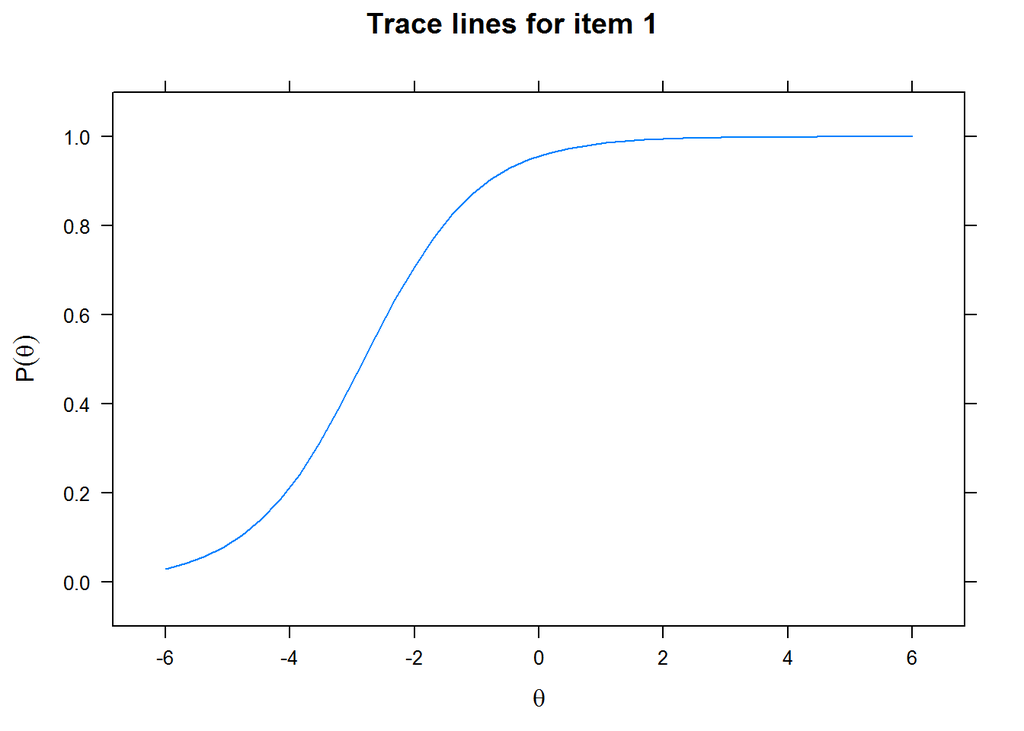

```r
> # krzywa charakterystyczna dla 1. zadania
> itemplot(wzrostBZ2PL, 1, type = "trace")
```

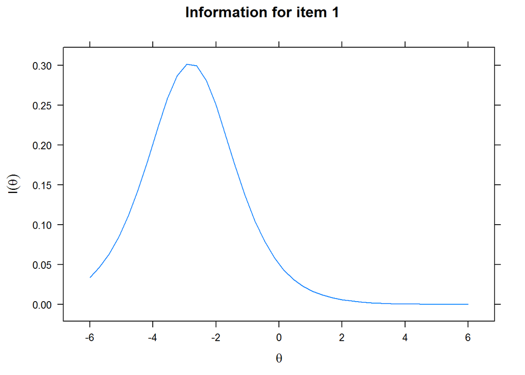

```r
> # krzywa informacyjna dla 1. zadania
> itemplot(wzrostBZ2PL, 1, type = "info")
```

### Krzywe charakterystyczne wszystkich zadań

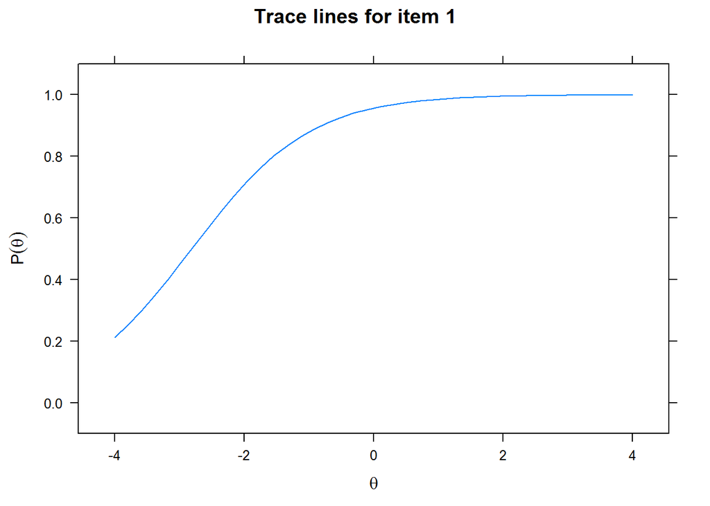

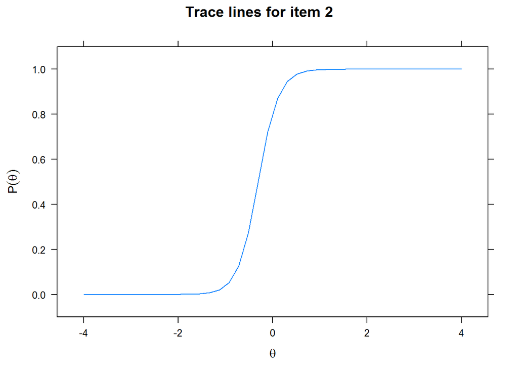

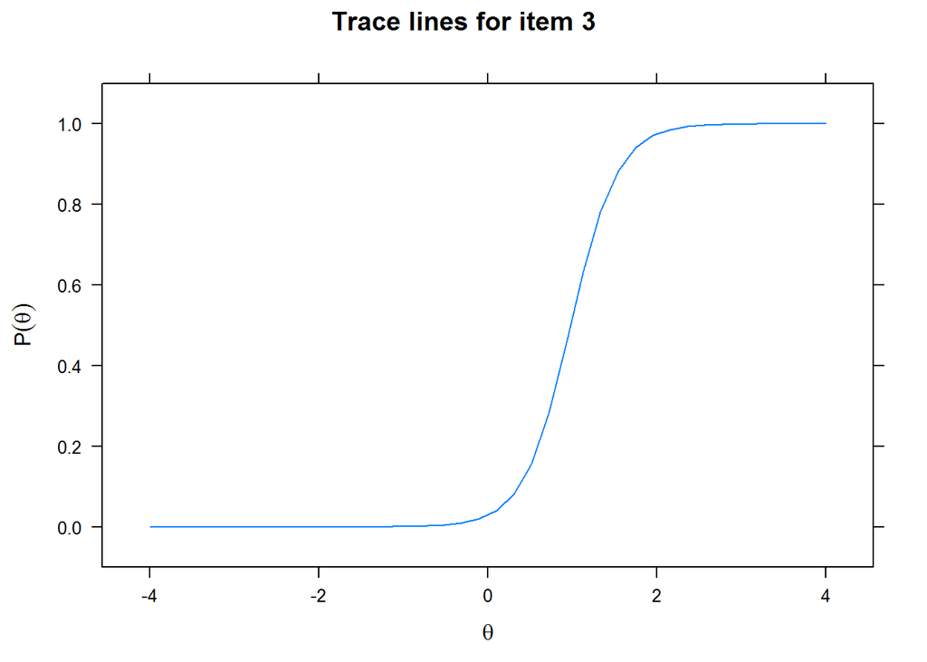

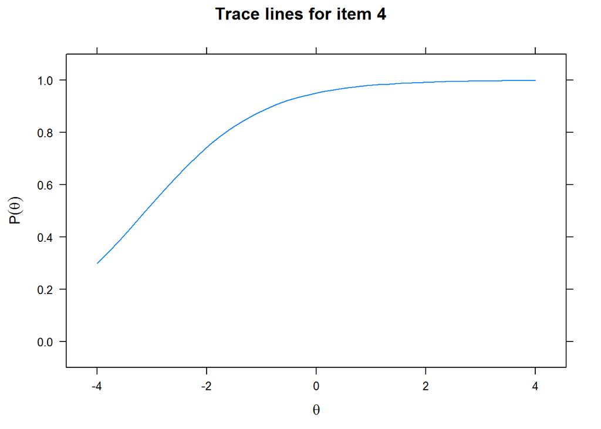

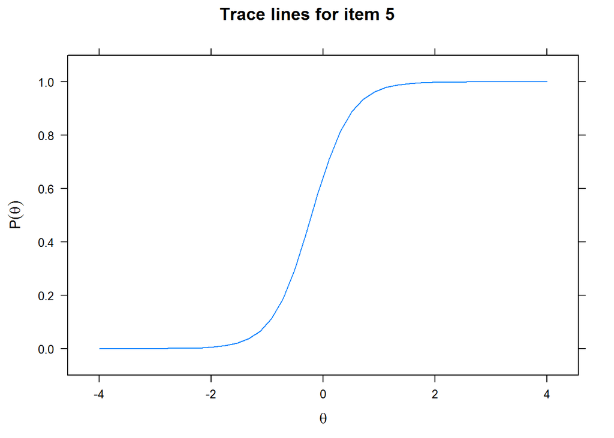

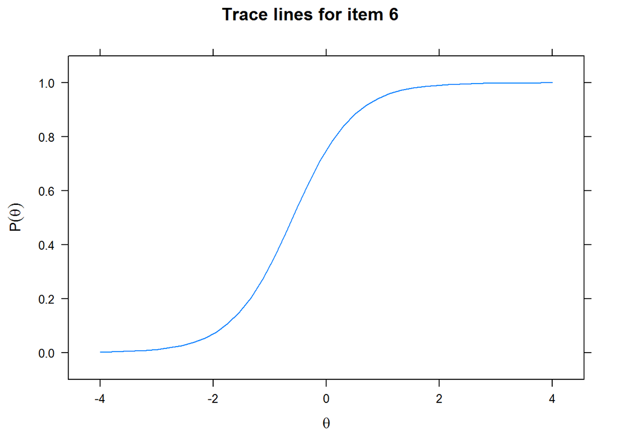

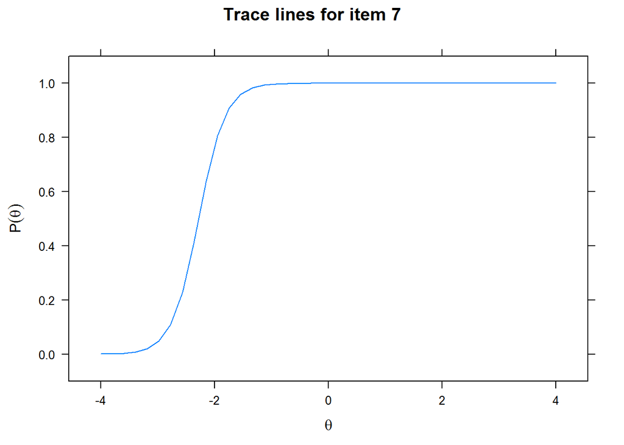

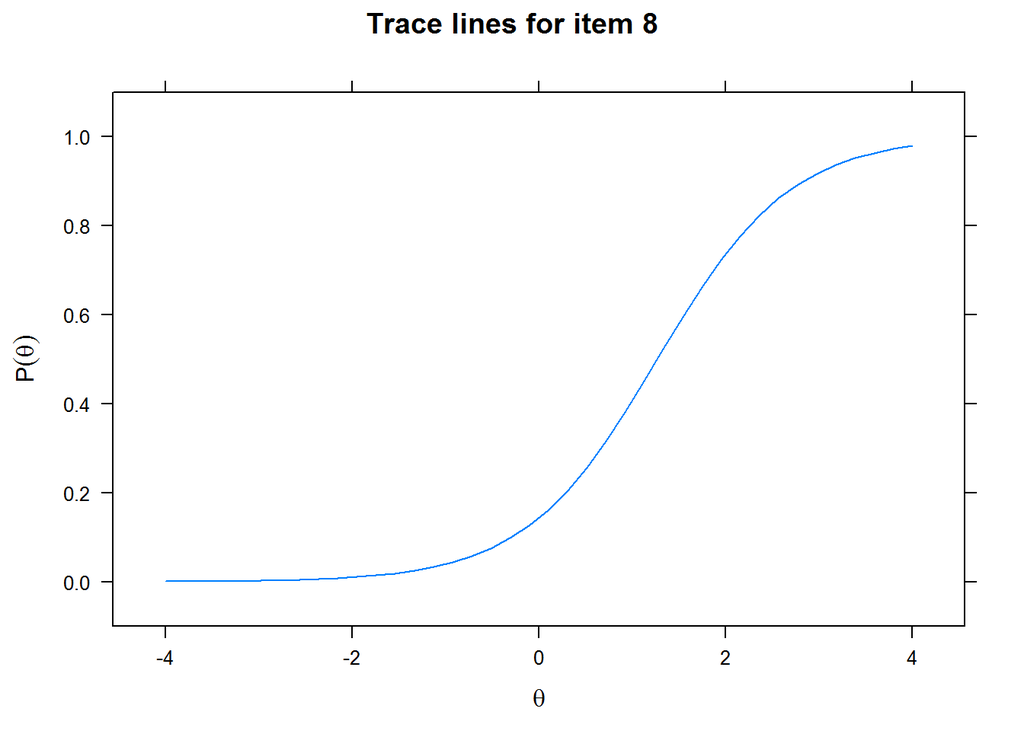

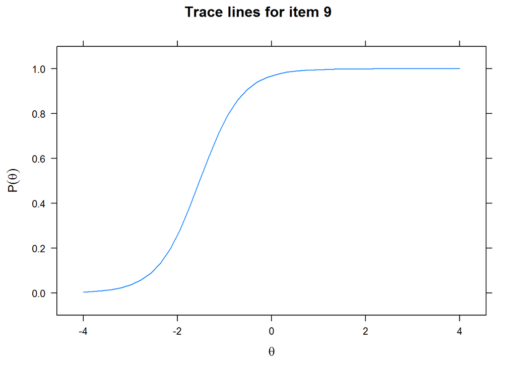

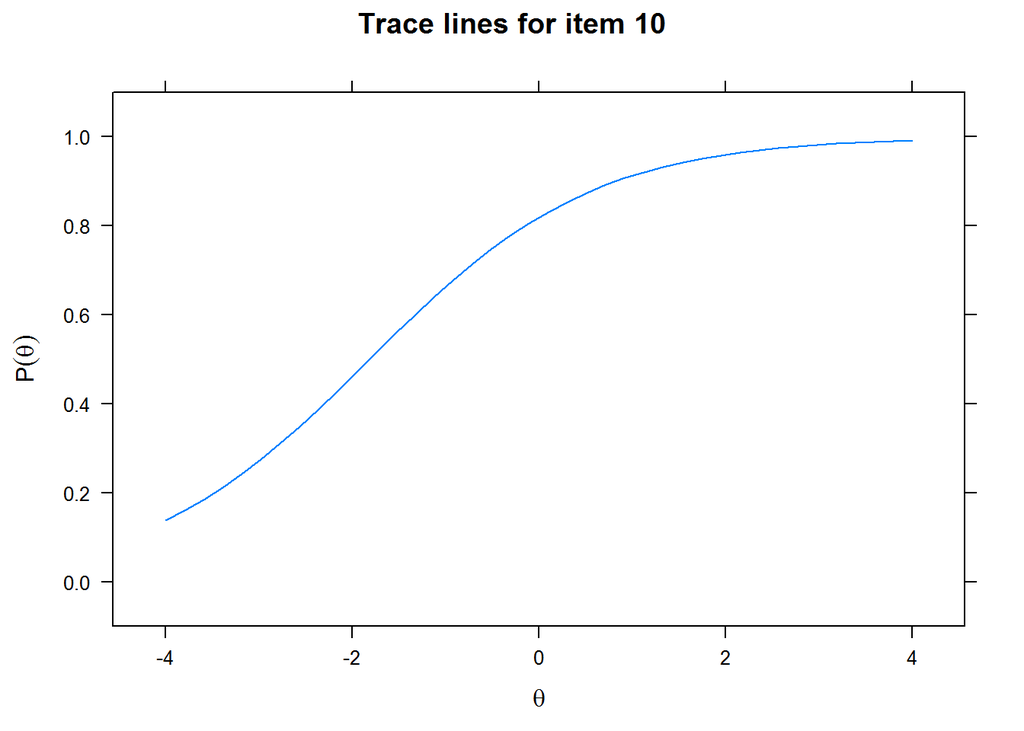

```r
> for (i in 1:10) {
+   plot(itemplot(wzrostBZ2PL, i, type = "trace", theta_lim = c(-4, 4)))
+ }
```

## Krzywa informacyjna testu

W pakiecie ‘mirt’ nie ma funkcji, która rysowałaby wykres krzywej informacyjnej testu, ale istnieje funkcja ‘testinfo()’, która pozwala obliczyć wartość informacji Fischera. Na podstawie zwróconych przez nią wyników możemy sami narysować krzywą informacyjną.

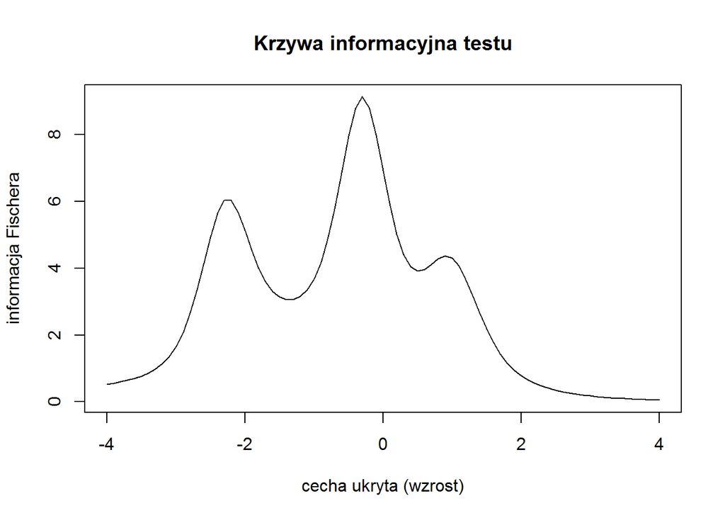

```r
> # wartości cechy, dla których ma zostać obliczona ilość inforacji
> x = seq(-4, 4, 0.1)
> # ilość informacji
> infoBZ2PL = testinfo(wzrostBZ2PL, x)
> # rysowanie
> plot(x, infoBZ2PL, type = "l", main = "Krzywa informacyjna testu",
+      xlab = "cecha ukryta (wzrost)", ylab = "informacja Fischera")
```

Korzystając z tego, że w danych z badania mamy informacje o wzroście badanych, skalę powyższego wykresu możemy wyrazić w centymetrach.

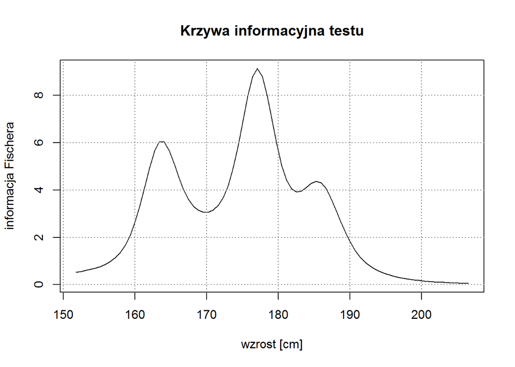

```r
> (sr = mean(daneWzrost$wzrost))
[1] 179.1395
> (odchStd = sd(daneWzrost$wzrost))
[1] 6.840292
> xCm = x * odchStd + sr
> plot(xCm, infoBZ2PL, type = "l", main = "Krzywa informacyjna testu",
+      xlab = "wzrost [cm]", ylab = "informacja Fischera")
> grid(col = grey(0.5))
```

Na ten sam wykres możemy chcieć nanieść krzywą informacyjną dla modelu Rascha, choć będzie to wymagało dodatkowych obliczeń.

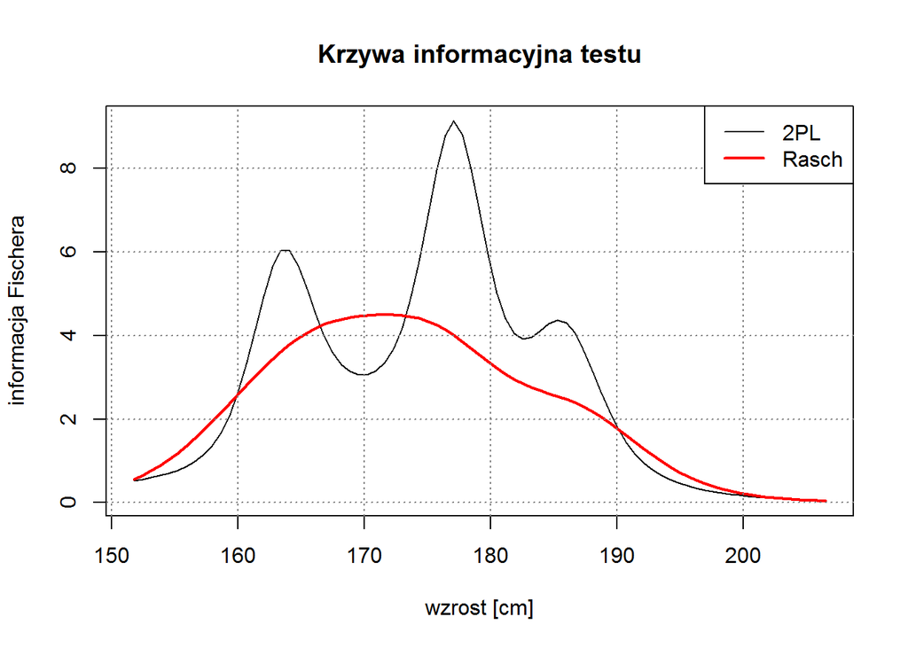

```r
> # wartości cechy, dla których ma zostać obliczona ilość inforacji
> xR = x * wspBZRasch$cov^0.5
> # ilość informacji
> infoBZRasch = testinfo(wzrostBZRasch, xR) * wspBZRasch$cov
> # krzywe informacyjna
> plot(xCm, infoBZ2PL, type = "l", main = "Krzywa informacyjna testu",
+      xlab = "wzrost [cm]", ylab = "informacja Fischera")
> lines(xCm, infoBZRasch, col = 2, lwd = 2)
> grid(col = grey(0.5))
> legend("topright", legend = c("2PL", "Rasch"), col = 1:2, lwd = 1:2)
```

Ilość informacji możemy też przeliczyć na wielkość standardowego błędu pomiaru (CSEM).

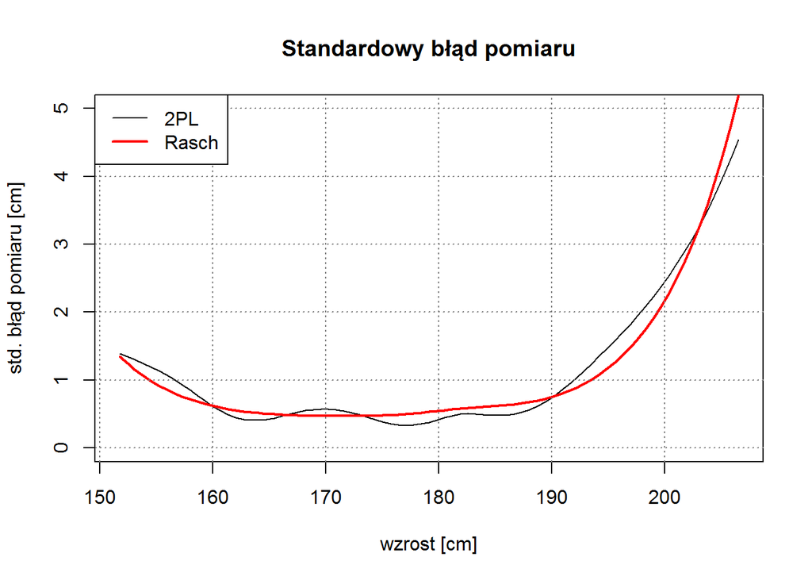

```r
> csemBZ2PL = 1 / infoBZ2PL^0.5
> csemBZRasch = 1 / infoBZRasch^0.5
> plot(xCm, csemBZ2PL, type = "l", main = "Standardowy błąd pomiaru",
+      xlab = "wzrost [cm]", ylab = "std. błąd pomiaru [cm]",
+      ylim = c(0, 5))
> lines(xCm, csemBZRasch, col = 2, lwd = 2)
> grid(col = grey(0.5))
> legend("topleft", legend = c("2PL", "Rasch"), col = 1:2, lwd = 1:2)
```

## Estymacja oszacowań wartości mierzonej cechy

Oszacowania wartości mierzonej cechy uzyskujemy przy pomocy funkcji ‘fscores()’ (jak widać nazwanej w konwencji analizy czynnikowej, nie IRT). Domyślnym typem estymatora jest EAP (Expected A’Posteriori) i przy nim pozostańmy. Argument ‘full.scores.SE = TRUE’ każe zwrócić również oszacowania błędów standardowych.

```r
> oszacBZ2PL = fscores(wzrostBZ2PL, full.scores.SE = TRUE)
> summary(oszacBZ2PL)
       F1                 SE_F1
 Min.   :-2.2931416   Min.   :0.3523
 1st Qu.:-0.6065319   1st Qu.:0.3737
 Median :-0.0071611   Median :0.4141
 Mean   : 0.0000481   Mean   :0.4228
 3rd Qu.: 0.6103325   3rd Qu.:0.4380
 Max.   : 1.5662931   Max.   :0.5817
> oszacBZRasch = fscores(wzrostBZRasch, full.scores.SE = TRUE)
> summary(oszacBZRasch)
       F1                SE_F1
 Min.   :-4.104899   Min.   :0.8086
 1st Qu.:-1.081499   1st Qu.:0.8361
 Median : 0.005086   Median :0.8851
 Mean   : 0.000530   Mean   :0.9102
 3rd Qu.: 0.838565   3rd Qu.:0.9426
 Max.   : 2.936163   Max.   :1.1180
```

Porównajmy własności oszacowań z modelu Rascha i z modelu 2PL, rysując wykresy rozrzutu. Przy tym, podobnie jak w przypadku krzywej informacyjnej, skorzystamy z tego, że znamy średnią i odchylenie standardowe wzrostu w badanej grupie i przeliczymy oszacowania tak, aby były wyrażone na skali wzrostu.

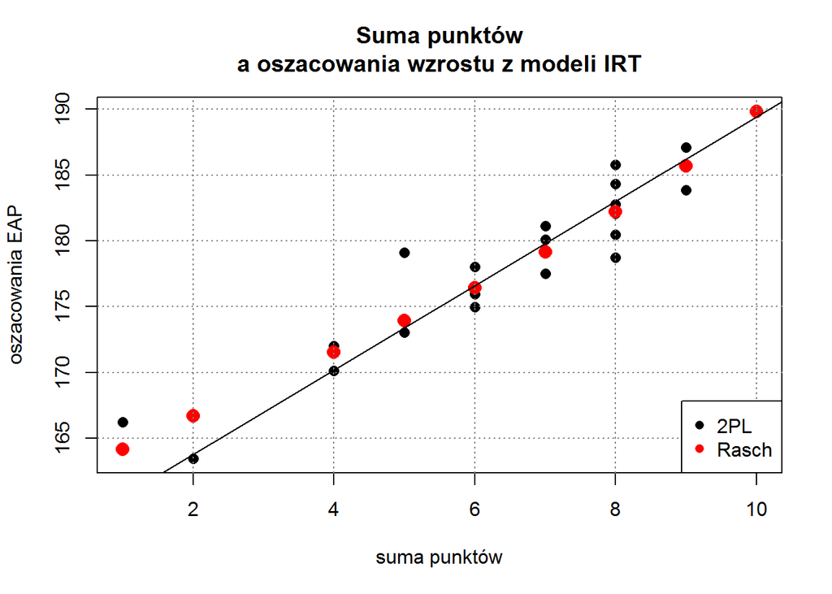

```r
> # suma punktów z testu bez zad. 1. i 3.
> sumaBZ = rowSums(wynikiWzrost[, -c(1, 3)])
> # przeliczamy oszacowania na wzrost w cm
> oszacBZ2PL[, 1] = oszacBZ2PL[, 1] * odchStd + sr
> oszacBZ2PL[, 2] = oszacBZ2PL[, 2] * odchStd
> oszacBZRasch[, 1] = oszacBZRasch[, 1] / wspBZRasch$cov^0.5 * odchStd + sr
> oszacBZRasch[, 2] = oszacBZRasch[, 2] / wspBZRasch$cov^0.5 * odchStd
> # rysowanie
> plot(sumaBZ, oszacBZ2PL[, 1], type = "p", pch = 16, col = 1, cex = 1.2,
+      main = "Suma punktów\na oszacowania wzrostu z modeli IRT",
+      xlab = "suma punktów", ylab = "oszacowania EAP")
> points(sumaBZ, oszacBZRasch[, 1], pch = 16, col = 2, cex = 1.5)
> grid(col = grey(0.5))
> legend("bottomright", legend = c("2PL", "Rasch"), pch = 16, col = 1:2)
> abline(sr - mean(sumaBZ) * odchStd / sd(sumaBZ), odchStd / sd(sumaBZ))
```

### Jak oszacowania mają się do (deklarowanej) rzeczywistości?

Obliczmy korelacje (liniowe Pearsona) pomiędzy różnymi oszacowaniami wzrostu, a tym, jaki wzrost zadeklarowali respondenci.

```r
> kor = cor(daneWzrost$wzrost,
+           data.frame(suma = rowSums(wynikiWzrost),
+                      sumaBZ = sumaBZ,
+                      oszacRashBZ = oszacBZRasch[, 1],
+                      oszac2PLBZ = oszacBZ2PL[, 1]))
> round(kor, 3)
      suma sumaBZ oszacRashBZ oszac2PLBZ
[1,] 0.741  0.712       0.708      0.714
```

**Przy tak niewielkiej liczbie obserwacji (i krótkim teście)** różnice w wartościach korelacji są niewielkie. Widać też, że chociaż zad. 1. i 3. sprawiały nam problemy w skalowaniu (przy czym zad. 1. głównie z powodu znikomego zróżnicowania rozkładu odpowiedzi - przy większej liczbie badanych problem ten zapewne by zniknął), to ich usunięcie zabiera nieco użytecznej informacji.

# Sprawdzian 2005 - zadania o wielu poziomach wykonania

## Przygotowanie danych

Wyniki sprawdzianu z 2005 r. (ściśle próba 10 tys. zdaących) znajdują się w obiekcie ‘daneSpr2005’, wczytywanym razem z pakietem ‘KTT’, a opis struktury testu w obiekcie ‘opisTestuSpr2005’. Analogicznie jak w przypadku wyników testu dotyczącego wzrostu musimy zapunktować je korzystając z funkcji ‘przypisz_punktacje()’.

```r
> spr = przypisz_punktacje(daneSpr2005, opisTestuSpr2005, verbose = FALSE)
>
> parametry_zadan(spr)
Parametry zadań:

test złożony z 37 zadań
10000 obserwacje (zdających)
w macierzy danych nie ma braków danych

rzetelność testu:
alfa Cronbacha  = 0.877
alfa Feldt-Raju = 0.888

 zadanie min. maks. trudność łatwość  MR-P MR-PBZ MR-DS rzetBZ-aC
      Z1    0     1     0.04    0.96 0.277  0.252 0.619 0.876
      Z2    0     1     0.16    0.84 0.518  0.480 0.782 0.873
      Z3    0     1     0.21    0.79 0.462  0.418 0.656 0.874
      Z4    0     1     0.08    0.92 0.441  0.410 0.798 0.874
      Z5    0     1     0.27    0.73 0.455  0.405 0.610 0.874
      Z6    0     1     0.45    0.55 0.397  0.338 0.499 0.875
      Z7    0     1     0.14    0.86 0.379  0.337 0.585 0.875
      Z8    0     1     0.11    0.89 0.336  0.297 0.554 0.876
      Z9    0     1     0.08    0.92 0.346  0.313 0.630 0.876
     Z10    0     1     0.23    0.77 0.368  0.317 0.512 0.875
     Z11    0     1     0.28    0.72 0.471  0.422 0.629 0.873
     Z12    0     1     0.19    0.81 0.314  0.265 0.456 0.876
     Z13    0     1     0.17    0.83 0.415  0.371 0.619 0.874
     Z14    0     1     0.41    0.59 0.256  0.192 0.324 0.878 (!)
     Z15    0     1     0.26    0.74 0.404  0.352 0.546 0.875
     Z16    0     1     0.05    0.95 0.353  0.328 0.767 0.876
     Z17    0     1     0.05    0.95 0.289  0.262 0.620 0.876
     Z18    0     1     0.36    0.64 0.339  0.280 0.436 0.876
     Z19    0     1     0.11    0.89 0.428  0.393 0.711 0.874
     Z20    0     1     0.26    0.74 0.364  0.311 0.494 0.875
   Z21_1    0     2     0.30    0.70 0.730  0.670    NA 0.866
   Z21_2    0     2     0.45    0.55 0.719  0.654    NA 0.867
   Z21_3    0     1     0.38    0.62 0.692  0.656 0.882 0.868
     Z22    0     1     0.19    0.81 0.303  0.254 0.441 0.876
   Z23_1    0     1     0.31    0.69 0.358  0.301 0.470 0.876
   Z23_2    0     1     0.04    0.96 0.210  0.184 0.480 0.877
   Z23_3    0     1     0.57    0.43 0.376  0.316 0.474 0.876
   Z23_4    0     1     0.39    0.61 0.363  0.304 0.462 0.876
   Z23_5    0     1     0.43    0.57 0.388  0.328 0.489 0.875
     Z24    0     1     0.12    0.88 0.264  0.222 0.428 0.877
   Z25_1    0     1     0.13    0.87 0.567  0.534 0.898 0.872
   Z25_2    0     1     0.26    0.74 0.595  0.554 0.804 0.871
   Z25_3    0     1     0.26    0.74 0.612  0.573 0.828 0.871
   Z25_4    0     1     0.62    0.38 0.454  0.399 0.578 0.874
   Z25_5    0     1     0.34    0.66 0.579  0.534 0.750 0.871
   Z25_6    0     1     0.32    0.68 0.546  0.500 0.712 0.872
     Z26    0     2     0.40    0.60 0.537  0.432    NA 0.877
 rzetBZ-aFR
  0.887
  0.884
  0.885
  0.886
  0.885
  0.887
  0.886
  0.887
  0.887
  0.887
  0.885
  0.887
  0.886
  0.889 (!)
  0.886
  0.887
  0.887
  0.888
  0.886
  0.887
  0.875
  0.876
  0.879
  0.888
  0.887
  0.888
  0.887
  0.887
  0.887
  0.888
  0.884
  0.883
  0.882
  0.886
  0.883
  0.884
  0.888

min.       - minimalna liczba punktów możliwych do uzyskania za zadanie
maks.      - maksymalna liczba punktów możliwych do uzyskania za zadanie
MR-P       - moc różnicująca: korelacja liniowa Pearsona (punktowo-dwuseryjna)
MR-PBZ     - moc różnicująca: korelacja Pearsona z sumą punktów z wyłączeniem danego zadania
MR-DS      - moc różnicująca: korelacja dwuseryjna
rzetBZ-aC  - rzetelność bez zadania: alfa Cronbacha
rzetBZ-aFR - rzetelność bez zadania: alfa Feldt-Raju
Zadania, po usunięciu których rzetelność rośnie oznaczono '(!)'
```

## Skalowanie

W teście znajdują się zarówno zadania oceniane binarnie, jak i trzy zadania oceniane na skali 0-1-2. Funkcja ‘mirt’ do skalowania zadań o wielu poziomach wykonania domyślnie używa modelu SGR (Samejima Graded Response), jednak do diagnostyki własności zadań bardziej użyteczny byłby model GPC (Generalised Partial Credit). Model skalowania możemy przy tym (a nawet musimy, jako że mamy w teście zadania różnych typów) opisać funkcji ‘mirt’ oddzielnie dla każdego zadania, przekazując jej jako argument ‘itemtype’ wektor ciągów znaków, którego kolejne elementy opisują model skalowania dla kolejnych zadań.

Możliwe modele dla zadań o wielu poziomach wykonania to:

- “grgm” - model Rasch Graded Response:
  - dyskryminacja taka sama dla wszystkich zadań, używany razem z typem “Rasch” dla zadań ocenianych binarnie,
  - nie dopuszcza zaburzenia kolejności podpunktów ze względu na trudność,
- “sgrm” - model Samejima Graded Response:
  - dyskryminacja estymowana oddzielnie dla każdego zadania,
  - nie dopuszcza zaburzenia kolejności podpunktów ze względu na trudność,
- “rpcm” - model Rasch Partial Credit:
  - dyskryminacja taka sama dla wszystkich zadań, używany razem z typem “Rasch” dla zadań ocenianych binarnie,
  - dopuszcza zaburzenia kolejności podpunktów ze względu na trudność,
- “gpcm” - model Generalised Partial Credit:
  - dyskryminacja estymowana oddzielnie dla każdego zadania,
  - dopuszcza zaburzenia kolejności podpunktów ze względu na trudność.

Poniżej tworzymy wektor opisujący model skalowania dla poszczególnych zadań i skalujemy wykorzystując funkcję ‘mirt’.

```r
> (modelZad = rep("2PL", ncol(spr)))
 [1] "2PL" "2PL" "2PL" "2PL" "2PL" "2PL" "2PL" "2PL" "2PL" "2PL" "2PL"
[12] "2PL" "2PL" "2PL" "2PL" "2PL" "2PL" "2PL" "2PL" "2PL" "2PL" "2PL"
[23] "2PL" "2PL" "2PL" "2PL" "2PL" "2PL" "2PL" "2PL" "2PL" "2PL" "2PL"
[34] "2PL" "2PL" "2PL" "2PL"
> # obiekt utworzony przez funkcję przypisz_punktację ma przypisane pewne
> #   użyteczne właściwości ('attributes')
> attributes(spr)$maks
 [1] 1 1 1 1 1 1 1 1 1 1 1 1 1 1 1 1 1 1 1 1 2 2 1 1 1 1 1 1 1 1 1 1 1 1 1
[36] 1 2
> # zadaniom, za które można było uzyskać maks. 2 pkt. przypiszmy wartość "gpcm"
> modelZad[attributes(spr)$maks == 2] = "gpcm"
> modelZad
 [1] "2PL"  "2PL"  "2PL"  "2PL"  "2PL"  "2PL"  "2PL"  "2PL"  "2PL"  "2PL"
[11] "2PL"  "2PL"  "2PL"  "2PL"  "2PL"  "2PL"  "2PL"  "2PL"  "2PL"  "2PL"
[21] "gpcm" "gpcm" "2PL"  "2PL"  "2PL"  "2PL"  "2PL"  "2PL"  "2PL"  "2PL"
[31] "2PL"  "2PL"  "2PL"  "2PL"  "2PL"  "2PL"  "gpcm"
>
> mSpr = mirt(spr, 1, itemptype = modelZad)

Iteration: 1, Log-Lik: -173506.511, Max-Change: 1.82266
Iteration: 2, Log-Lik: -170278.313, Max-Change: 1.16768
Iteration: 3, Log-Lik: -169170.431, Max-Change: 0.67451
Iteration: 4, Log-Lik: -168853.309, Max-Change: 0.54538
Iteration: 5, Log-Lik: -168609.050, Max-Change: 0.38943
Iteration: 6, Log-Lik: -168501.347, Max-Change: 0.34223
Iteration: 7, Log-Lik: -168440.536, Max-Change: 0.30060
Iteration: 8, Log-Lik: -168400.987, Max-Change: 0.27377
Iteration: 9, Log-Lik: -168378.910, Max-Change: 0.25036
Iteration: 10, Log-Lik: -168358.276, Max-Change: 0.23264
Iteration: 11, Log-Lik: -168348.751, Max-Change: 0.19903
Iteration: 12, Log-Lik: -168340.126, Max-Change: 0.20693
Iteration: 13, Log-Lik: -168332.713, Max-Change: 0.19271
Iteration: 14, Log-Lik: -168327.124, Max-Change: 0.17870
Iteration: 15, Log-Lik: -168322.078, Max-Change: 0.16702
Iteration: 16, Log-Lik: -168318.523, Max-Change: 0.15642
Iteration: 17, Log-Lik: -168314.962, Max-Change: 0.16432
Iteration: 18, Log-Lik: -168311.328, Max-Change: 0.15430
Iteration: 19, Log-Lik: -168305.725, Max-Change: 0.11392
Iteration: 20, Log-Lik: -168301.686, Max-Change: 0.10839
Iteration: 21, Log-Lik: -168300.434, Max-Change: 0.10935
Iteration: 22, Log-Lik: -168297.084, Max-Change: 0.09414
Iteration: 23, Log-Lik: -168295.983, Max-Change: 0.09106
Iteration: 24, Log-Lik: -168295.476, Max-Change: 0.06720
Iteration: 25, Log-Lik: -168294.633, Max-Change: 0.11077
Iteration: 26, Log-Lik: -168294.247, Max-Change: 0.00007
> coef(mSpr, IRTpar = TRUE, simplify = TRUE)
$items
          a      b  g  u     b1     b2
Z1    1.222 -3.087  0  1     NA     NA
Z2    1.613 -1.465  0  1     NA     NA
Z3    1.140 -1.467  0  1     NA     NA
Z4    1.645 -2.045  0  1     NA     NA
Z5    1.015 -1.167  0  1     NA     NA
Z6    0.772 -0.322  0  1     NA     NA
Z7    1.005 -2.095  0  1     NA     NA
Z8    0.935 -2.543  0  1     NA     NA
Z9    1.209 -2.481  0  1     NA     NA
Z10   0.806 -1.734  0  1     NA     NA
Z11   1.056 -1.094  0  1     NA     NA
Z12   0.684 -2.367  0  1     NA     NA
Z13   1.081 -1.809  0  1     NA     NA
Z14   0.402 -0.934  0  1     NA     NA
Z15   0.877 -1.379  0  1     NA     NA
Z16   1.670 -2.491  0  1     NA     NA
Z17   1.229 -2.965  0  1     NA     NA
Z18   0.633 -1.009  0  1     NA     NA
Z19   1.363 -1.981  0  1     NA     NA
Z20   0.797 -1.524  0  1     NA     NA
Z21_1 5.762     NA NA NA -0.746 -0.352
Z21_2 3.811     NA NA NA -0.445  0.187
Z21_3 8.036 -0.309  0  1     NA     NA
Z22   0.647 -2.487  0  1     NA     NA
Z23_1 0.696 -1.280  0  1     NA     NA
Z23_2 0.894 -3.992  0  1     NA     NA
Z23_3 0.716  0.454  0  1     NA     NA
Z23_4 0.665 -0.770  0  1     NA     NA
Z23_5 0.704 -0.453  0  1     NA     NA
Z24   0.669 -3.223  0  1     NA     NA
Z25_1 2.022 -1.478  0  1     NA     NA
Z25_2 1.631 -0.927  0  1     NA     NA
Z25_3 1.709 -0.914  0  1     NA     NA
Z25_4 0.979  0.600  0  1     NA     NA
Z25_5 1.418 -0.658  0  1     NA     NA
Z25_6 1.265 -0.775  0  1     NA     NA
Z26   1.060     NA NA NA -0.489 -0.442

$means
F1
 0

$cov
   F1
F1  1
```

## Diagnostyka graficzna

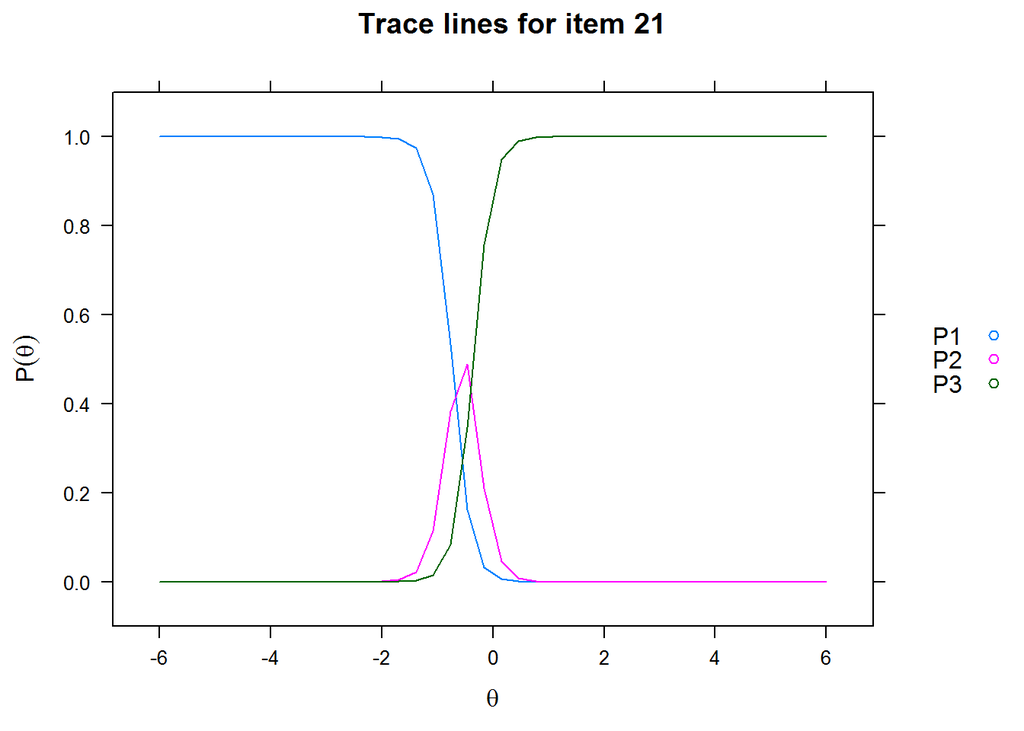

```r
> itemplot(mSpr, 21, type = "trace")
```

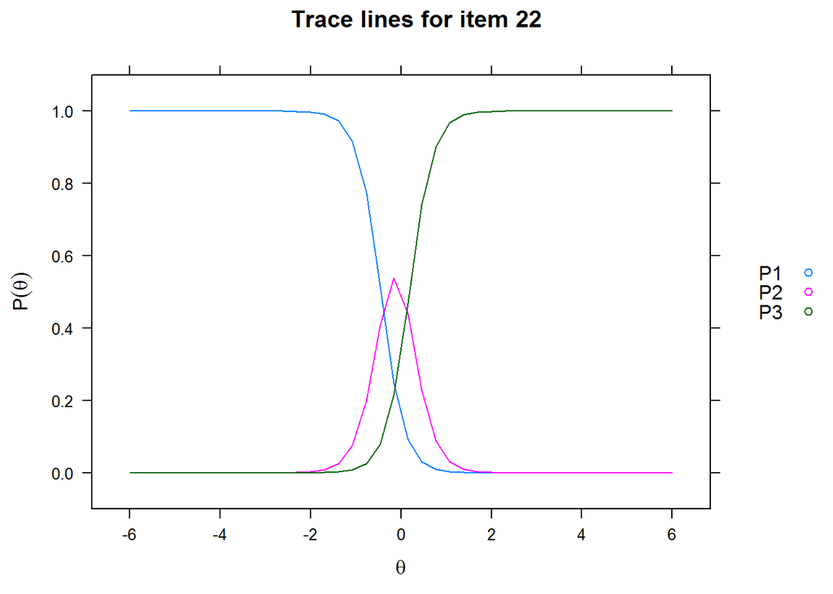

```r
> table(spr$Z21_1)

   0    1    2
2358 1341 6301
> prop.table(table(spr$Z21_1))

     0      1      2
0.2358 0.1341 0.6301
> itemplot(mSpr, 22, type = "trace")
```

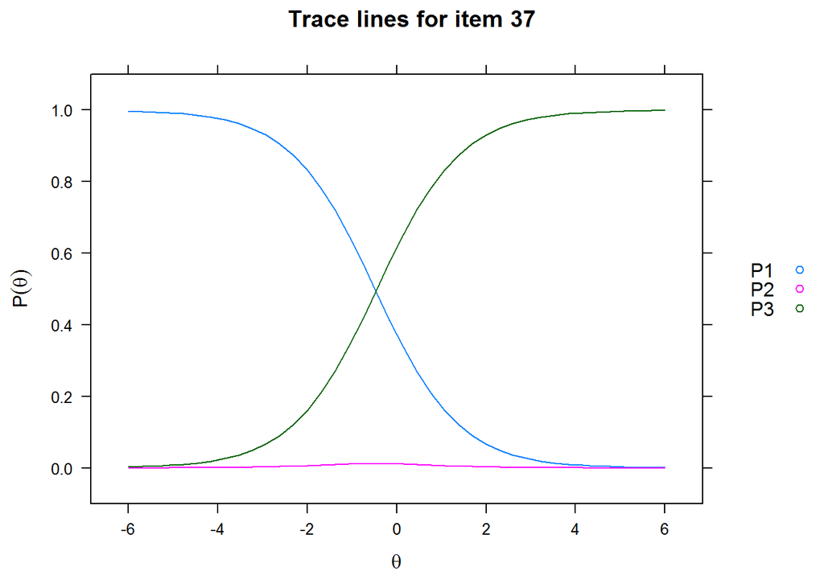

```r
> table(spr$Z21_2)

   0    1    2
3398 2271 4331
> prop.table(table(spr$Z21_2))

     0      1      2
0.3398 0.2271 0.4331
> itemplot(mSpr, 37, type = "trace")
```

```r
> table(spr$Z26)

   0    1    2
3975   97 5928
> prop.table(table(spr$Z26))

     0      1      2
0.3975 0.0097 0.5928
```

Jak widać, w zad. 26. środkowa pozycja skali oceny jest bardzo rzadko wykorzystywana. Gdyby chcieć je wykorzystywać w przyszłości w innych testach, należałoby przemyśleć zmianę klucza kodowania.